# Lemurs

## Set Up

```r
library(tidyverse)
library(skimr)
```

## Import

```r
# use tidytuesdayR package to read 'taxonomy' data only
## parsing failure with lemurs data
taxonomy <- tidytuesdayR::tt_load(2021, week = 35, download_files = "taxonomy") %>% .$taxonomy
```

```
## --- Compiling #TidyTuesday Information for 2021-08-24 ----
```

```
## --- There are 2 files available ---
```

```
## --- Starting Download ---
```

```
## --- Download complete ---
```

```r
# read lemurs file sorting out parsing failure
lemurs <- readr::read_csv('https://raw.githubusercontent.com/rfordatascience/tidytuesday/master/data/2021/2021-08-24/lemur_data.csv',
                          col_types = cols(
                            age_of_living_y = col_double()))
```

## Tidying and Transformation

### Join datasets

Join both datasets so can use common names rather than ‘taxon’ codes. First attempt resulted in missing values so explored any differences between the two sets of data and re_joined

```r
# need to explore taxonomy dataset and look for error ?taxon codes that don't match
anti_join(lemurs, taxonomy) %>%
  distinct(taxon) %>% .$taxon
```

```
## [1] "CMED"
```

```r
# taxon = "CMED" in one set "CMEAD" in the other --> NA when left join
# recode so these match
taxonomy$taxon <-
  taxonomy$taxon %>%
  fct_recode(CMED = "CMEAD")
# join both datasets so can use common names rather than 'taxon' codes
lemurs <- lemurs %>%
  left_join(taxonomy) %>%
  select(common_name, everything())
```

### Single row for each individual lemur

Group_together data for each individual lemur so each lemur is represented by a single row. Multiple rows exist due to weight data for different ages. Can use original dataset to look at weight data and this new data_frame to look at individual lemurs.

There are 2 different hybrid species both coded as ‘hybrid’ so they are joined together when grouping by ‘common’ name. This distorts the data so I chose to exclude hybrid species from my analysis.

```r
lemurs_distinct <- distinct(lemurs, dlc_id, .keep_all = TRUE) %>%
  filter(common_name != "hybrid")
```

### Choose top species

Create new object - a data-frame containing data for the *n* commonest species.

```r
n <- 10
top_species <- lemurs_distinct %>%
  group_by(common_name) %>%
  count() %>%
  arrange(desc(n)) %>%
  head(n) %>%
  pull(common_name)
top_species<- lemurs_distinct %>%
  filter(common_name %in% top_species)
```

## Exploration

### Descriptive statistics

```r
skim(lemurs)
```

Data summary

| Name | lemurs |
| --- | --- |
| Number of rows | 82609 |
| Number of columns | 56 |
| _______________________ |  |
| Column type frequency: |  |
| character | 21 |
| Date | 8 |
| numeric | 27 |
| ________________________ |  |
| Group variables | None |

**Variable type: character**

| skim_variable | n_missing | complete_rate | min | max | empty | n_unique | whitespace |
| --- | --- | --- | --- | --- | --- | --- | --- |
| common_name | 0 | 1.00 | 5 | 28 | 0 | 26 | 0 |
| taxon | 0 | 1.00 | 3 | 4 | 0 | 27 | 0 |
| dlc_id | 0 | 1.00 | 3 | 4 | 0 | 2270 | 0 |
| hybrid | 0 | 1.00 | 1 | 2 | 0 | 2 | 0 |
| sex | 0 | 1.00 | 1 | 2 | 0 | 3 | 0 |
| name | 0 | 1.00 | 2 | 19 | 0 | 2244 | 0 |
| current_resident | 0 | 1.00 | 1 | 1 | 0 | 2 | 0 |
| stud_book | 2745 | 0.97 | 1 | 7 | 0 | 1234 | 0 |
| estimated_dob | 72080 | 0.13 | 1 | 3 | 0 | 8 | 0 |
| birth_type | 0 | 1.00 | 2 | 3 | 0 | 3 | 0 |
| birth_institution | 0 | 1.00 | 7 | 44 | 0 | 88 | 0 |
| dam_id | 1056 | 0.99 | 3 | 9 | 0 | 581 | 0 |
| dam_name | 15239 | 0.82 | 2 | 15 | 0 | 498 | 0 |
| dam_taxon | 15239 | 0.82 | 3 | 4 | 0 | 27 | 0 |
| sire_id | 1761 | 0.98 | 3 | 9 | 0 | 501 | 0 |
| sire_name | 24855 | 0.70 | 2 | 17 | 0 | 420 | 0 |
| sire_taxon | 24855 | 0.70 | 3 | 4 | 0 | 26 | 0 |
| dob_estimated | 72080 | 0.13 | 1 | 3 | 0 | 8 | 0 |
| age_category | 0 | 1.00 | 2 | 11 | 0 | 3 | 0 |
| preg_status | 0 | 1.00 | 1 | 2 | 0 | 2 | 0 |
| latin_name | 0 | 1.00 | 11 | 28 | 0 | 27 | 0 |

**Variable type: Date**

| skim_variable | n_missing | complete_rate | min | max | median | n_unique |
| --- | --- | --- | --- | --- | --- | --- |
| dob | 8 | 1.00 | 1946-10-01 | 2018-07-24 | 1994-03-20 | 1534 |
| estimated_concep | 8 | 1.00 | 1946-06-03 | 2018-05-22 | 1993-11-01 | 1572 |
| dam_dob | 15239 | 0.82 | 1958-10-01 | 2015-01-08 | 1986-06-26 | 428 |
| sire_dob | 24855 | 0.70 | 1946-10-01 | 2014-08-07 | 1985-11-29 | 377 |
| dod | 37361 | 0.55 | 1969-06-02 | 2019-01-15 | 2008-11-13 | 1339 |
| weight_date | 0 | 1.00 | 1968-09-16 | 2019-02-05 | 2005-12-14 | 10291 |
| concep_date_if_preg | 80692 | 0.02 | 1971-11-09 | 2018-05-22 | 2003-09-11 | 656 |
| infant_dob_if_preg | 80692 | 0.02 | 1972-03-08 | 2018-07-24 | 2004-02-18 | 639 |

**Variable type: numeric**

| skim_variable | n_missing | complete_rate | mean | sd | p0 | p25 | p50 | p75 | p100 | hist |
| --- | --- | --- | --- | --- | --- | --- | --- | --- | --- | --- |
| birth_month | 8 | 1.00 | 5.58 | 2.70 | 1.00 | 4.00 | 5.00 | 7.00 | 12.00 | ▇▇▇▃▃ |
| litter_size | 18169 | 0.78 | 1.65 | 0.82 | 1.00 | 1.00 | 1.00 | 2.00 | 4.00 | ▇▅▁▂▁ |
| expected_gestation | 0 | 1.00 | 119.50 | 39.71 | 62.00 | 90.00 | 124.00 | 160.00 | 193.00 | ▆▃▇▅▂ |
| concep_month | 8 | 1.00 | 6.62 | 3.69 | 1.00 | 4.00 | 6.00 | 11.00 | 12.00 | ▆▆▃▂▇ |
| dam_age_at_concep_y | 15247 | 0.82 | 7.18 | 4.63 | 0.59 | 3.62 | 6.43 | 10.16 | 26.03 | ▇▆▂▁▁ |
| sire_age_at_concep_y | 24863 | 0.70 | 9.12 | 6.27 | 0.61 | 4.63 | 7.44 | 12.44 | 33.36 | ▇▅▂▁▁ |
| age_at_death_y | 37369 | 0.55 | 17.51 | 8.43 | 0.00 | 11.13 | 17.36 | 23.40 | 39.39 | ▃▇▇▅▂ |
| age_of_living_y | 53479 | 0.35 | 13.49 | 8.88 | 0.54 | 6.62 | 10.65 | 19.81 | 35.20 | ▇▇▃▃▂ |
| age_last_verified_y | 74378 | 0.10 | 12.87 | 8.21 | 0.36 | 6.74 | 10.33 | 19.14 | 34.26 | ▆▇▃▃▂ |
| age_max_live_or_dead_y | 8 | 1.00 | 15.63 | 8.82 | 0.00 | 7.81 | 14.56 | 22.54 | 39.39 | ▇▇▆▅▂ |
| n_known_offspring | 36563 | 0.56 | 5.59 | 4.75 | 1.00 | 2.00 | 4.00 | 7.00 | 36.00 | ▇▂▁▁▁ |
| weight_g | 0 | 1.00 | 1485.81 | 1313.24 | 4.74 | 199.00 | 1310.00 | 2480.00 | 10337.00 | ▇▅▁▁▁ |
| month_of_weight | 0 | 1.00 | 6.50 | 3.40 | 1.00 | 4.00 | 7.00 | 9.00 | 12.00 | ▇▆▆▆▇ |
| age_at_wt_d | 8 | 1.00 | 3102.37 | 2823.60 | 0.00 | 768.00 | 2303.00 | 4808.00 | 14373.00 | ▇▃▂▁▁ |
| age_at_wt_wk | 8 | 1.00 | 443.20 | 403.37 | 0.00 | 109.71 | 329.00 | 686.86 | 2053.29 | ▇▃▂▁▁ |
| age_at_wt_mo | 8 | 1.00 | 102.00 | 92.83 | 0.00 | 25.25 | 75.72 | 158.07 | 472.54 | ▇▃▂▁▁ |
| age_at_wt_mo_no_dec | 8 | 1.00 | 101.51 | 92.82 | 0.00 | 25.00 | 75.00 | 158.00 | 472.00 | ▇▃▂▁▁ |
| age_at_wt_y | 8 | 1.00 | 8.50 | 7.74 | 0.00 | 2.10 | 6.31 | 13.17 | 39.38 | ▇▃▂▁▁ |
| change_since_prev_wt_g | 2253 | 0.97 | 20.05 | 176.30 | -1760.00 | -20.00 | 2.00 | 48.00 | 4303.00 | ▁▇▁▁▁ |
| days_since_prev_wt | 2253 | 0.97 | 55.15 | 147.18 | 0.00 | 13.00 | 28.00 | 55.00 | 7113.00 | ▇▁▁▁▁ |
| avg_daily_wt_change_g | 2470 | 0.97 | 0.59 | 11.22 | -920.00 | -0.63 | 0.13 | 1.81 | 300.00 | ▁▁▁▇▁ |
| days_before_death | 37361 | 0.55 | 2693.57 | 2280.20 | 0.00 | 852.00 | 2099.00 | 4063.00 | 13052.00 | ▇▃▂▁▁ |
| r_min_dam_age_at_concep_y | 0 | 1.00 | 1.56 | 0.91 | 0.40 | 0.79 | 1.53 | 1.76 | 4.22 | ▆▇▂▁▁ |
| expected_gestation_d | 80692 | 0.02 | 141.28 | 33.37 | 62.00 | 124.00 | 145.00 | 160.00 | 193.00 | ▂▂▇▇▅ |
| days_before_inf_birth_if_preg | 80692 | 0.02 | 67.74 | 46.35 | 0.00 | 28.00 | 62.00 | 104.00 | 193.00 | ▇▆▅▃▁ |
| pct_preg_remain_if_preg | 80692 | 0.02 | 0.48 | 0.30 | 0.00 | 0.21 | 0.48 | 0.74 | 1.00 | ▇▆▆▇▆ |
| infant_lit_sz_if_preg | 80704 | 0.02 | 1.30 | 0.58 | 1.00 | 1.00 | 1.00 | 1.00 | 4.00 | ▇▂▁▁▁ |

```r
descriptive <- lemurs %>%
  select(c(birth_month, age_at_death_y, litter_size, n_known_offspring)) %>%
  psych::describe() %>%
  select(-(c(vars)))
descriptive
```

|  | n | mean | sd | median | trimmed | mad | min | max | range | skew | kurtosis | se |
| --- | --- | --- | --- | --- | --- | --- | --- | --- | --- | --- | --- | --- |
| birth_month | 82601 | 5.577196 | 2.7008339 | 5.00 | 5.384135 | 2.96520 | 1 | 12.00 | 11.00 | 0.5828802 | -0.2277316 | 0.009397346 |
| age_at_death_y | 45240 | 17.506567 | 8.4291638 | 17.36 | 17.407306 | 9.19212 | 0 | 39.39 | 39.39 | 0.1010638 | -0.6790902 | 0.039629920 |
| litter_size | 64440 | 1.652452 | 0.8160686 | 1.00 | 1.529465 | 0.00000 | 1 | 4.00 | 3.00 | 1.0342076 | 0.1959530 | 0.003214763 |
| n_known_offspring | 46046 | 5.591148 | 4.7487074 | 4.00 | 4.767848 | 2.96520 | 1 | 36.00 | 35.00 | 1.7019482 | 3.5509613 | 0.022129900 |

## Visualisation

### Distribution of species

#### Overall

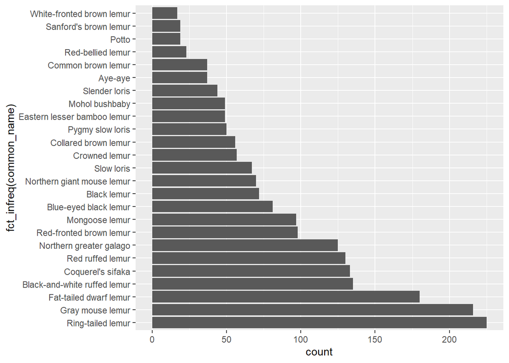

```r
lemurs_distinct %>%
  ggplot(aes(x = fct_infreq(common_name)))+
  geom_bar()+
  coord_flip()
```

#### Top n species

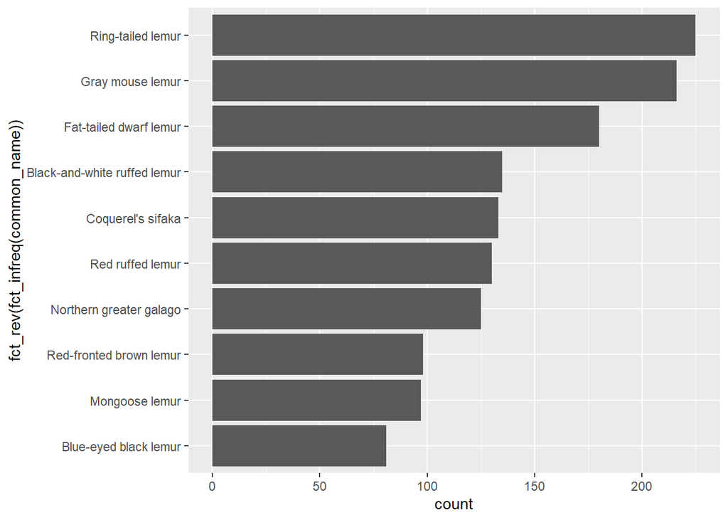

```r
top_species %>%
  ggplot(aes(x = fct_rev(fct_infreq(common_name))))+
  geom_bar()+
  coord_flip()
```

#### Birth Month

Explore distribution of months of birth.

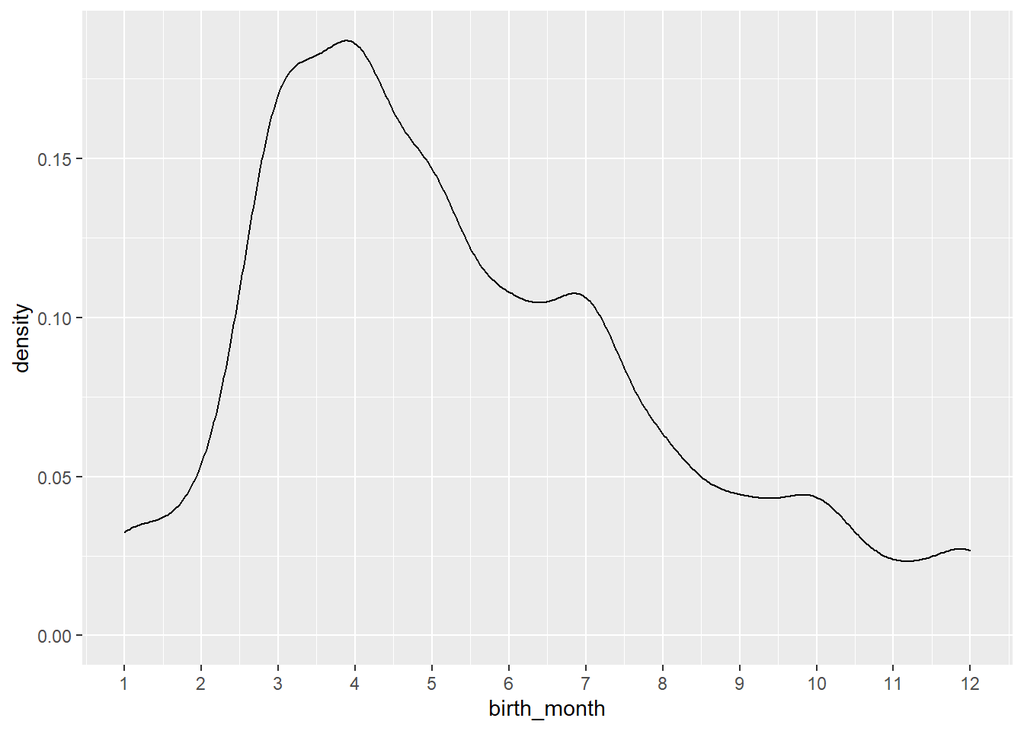

```r
lemurs_distinct %>%
  mutate(birth_month = as.integer(birth_month)) %>%
  ggplot()+
  geom_density(aes(x = birth_month))+
  scale_x_continuous(breaks = c(1:12), labels = c(1:12))
```

Birth month is a discrete variable so convert numbers to month abbreviation and re-plot as a bar chart. Will need to produce an ordered factor for birth month and exclude NA. Also filter for captive born only and exclude any estimated dob.

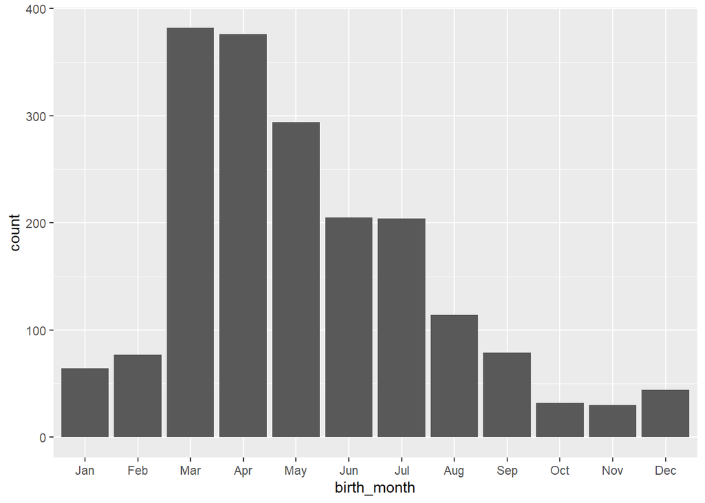

```r
lemurs_distinct %>%
  drop_na(birth_month) %>%
  filter(birth_type == "CB" & is.na(estimated_dob)) %>%
  mutate(birth_month = month.abb[birth_month],
         birth_month = factor(birth_month,
                              levels = month.abb,
                              ordered = TRUE)) %>%
  ggplot(aes(x = birth_month))+
  geom_bar()
```

#### Age at death

Filter for those with known dob and known dod

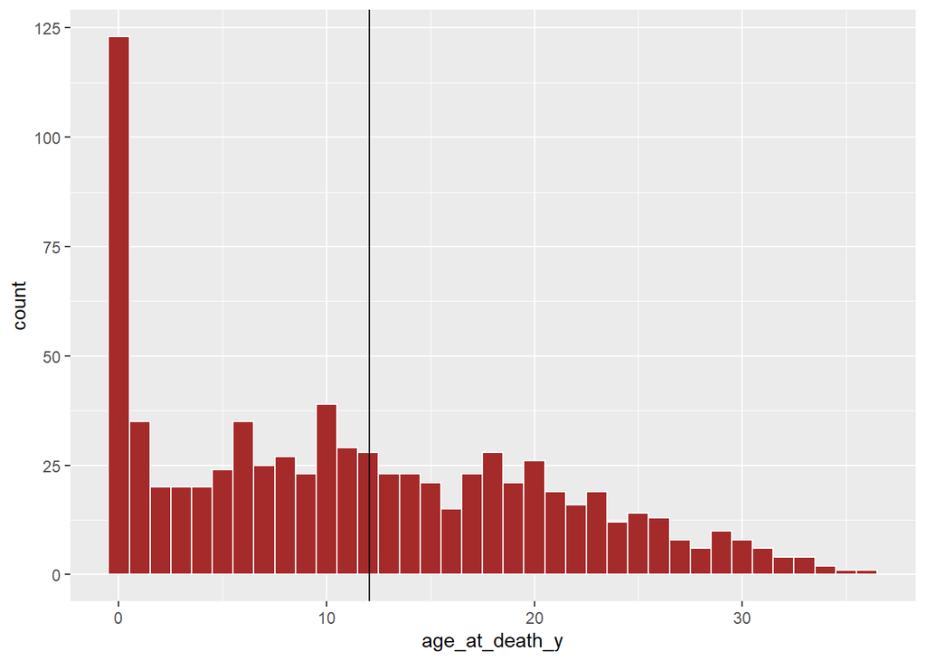

```r
top_species %>%
  filter(!is.na(dob) & !is.na(dod) & birth_type == "CB"
         & is.na(estimated_dob)) %>%
  ggplot(aes(x = age_at_death_y))+
  geom_histogram(binwidth = 1, colour = "white", fill = "brown")+
  geom_vline(xintercept = 12.05)
```

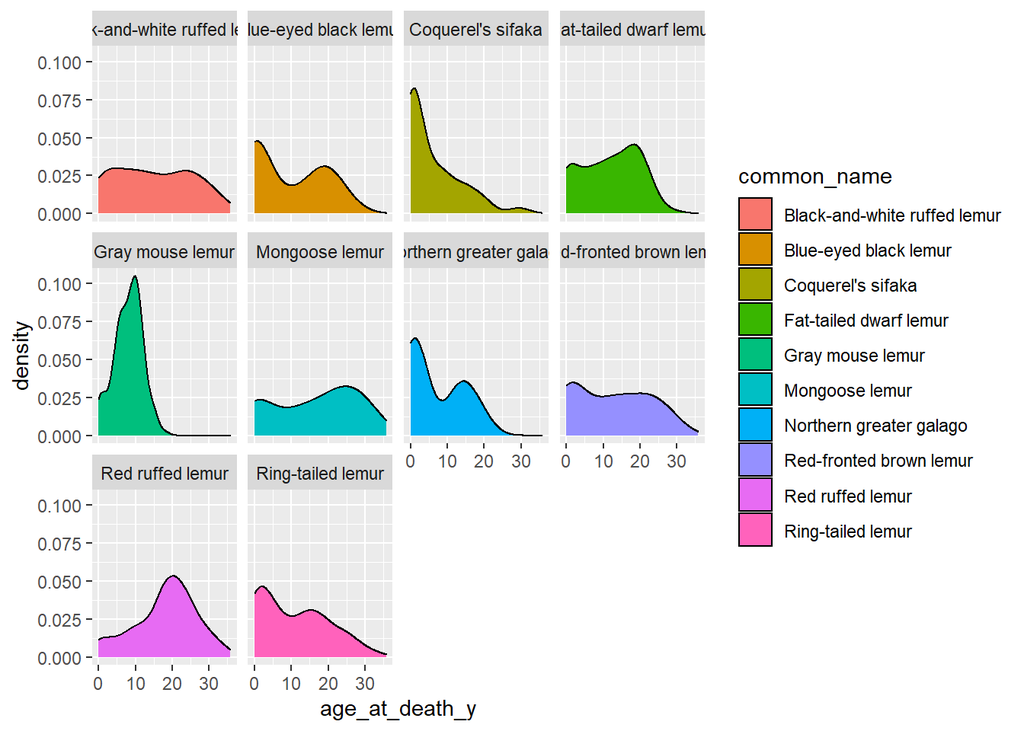

```r
top_species %>%
  filter(!is.na(dob) & !is.na(dod) & birth_type == "CB"
         & is.na(estimated_dob)) %>%
  filter(!is.na(common_name) & common_name != "hybrid") %>%
  ggplot(aes(x = age_at_death_y))+
  geom_density(aes(fill = common_name))+
  facet_wrap(~ common_name)
```

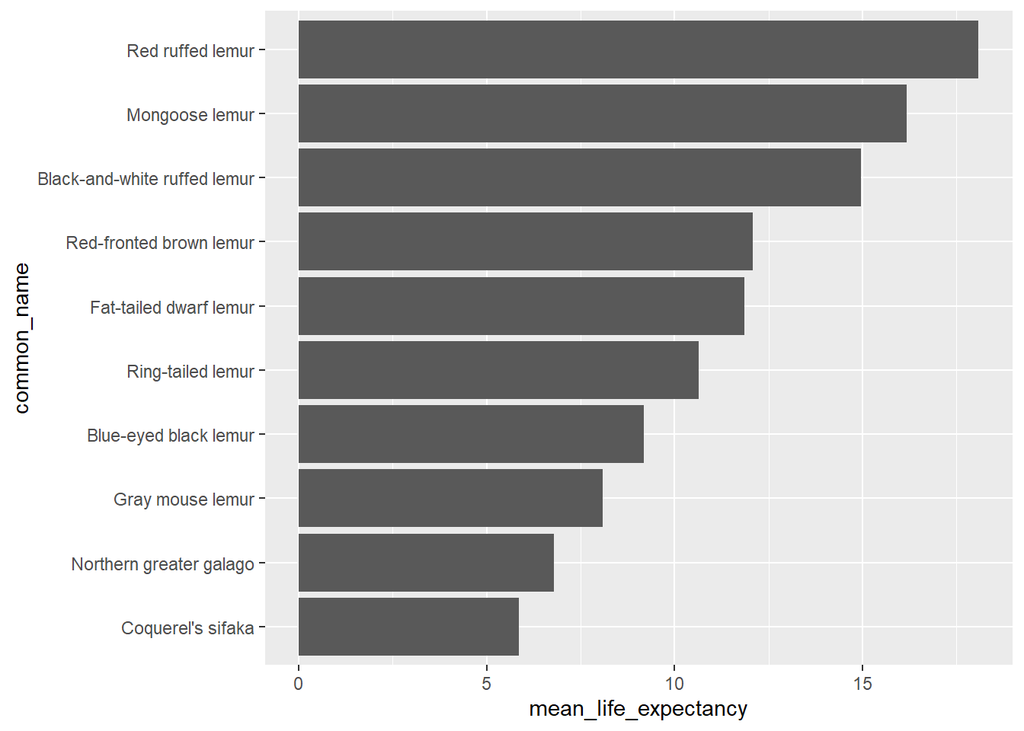

```r
top_species %>%
  filter(!is.na(dob) & !is.na(dod) & birth_type == "CB"
         & is.na(estimated_dob)) %>%
  group_by(common_name) %>%
  summarise(mean_life_expectancy = mean (age_at_death_y, na.rm = TRUE)) %>%
  mutate (common_name = fct_reorder(common_name, mean_life_expectancy)) %>%
  ggplot()+
  geom_col(aes(x = common_name, y = mean_life_expectancy))+
  coord_flip()
```

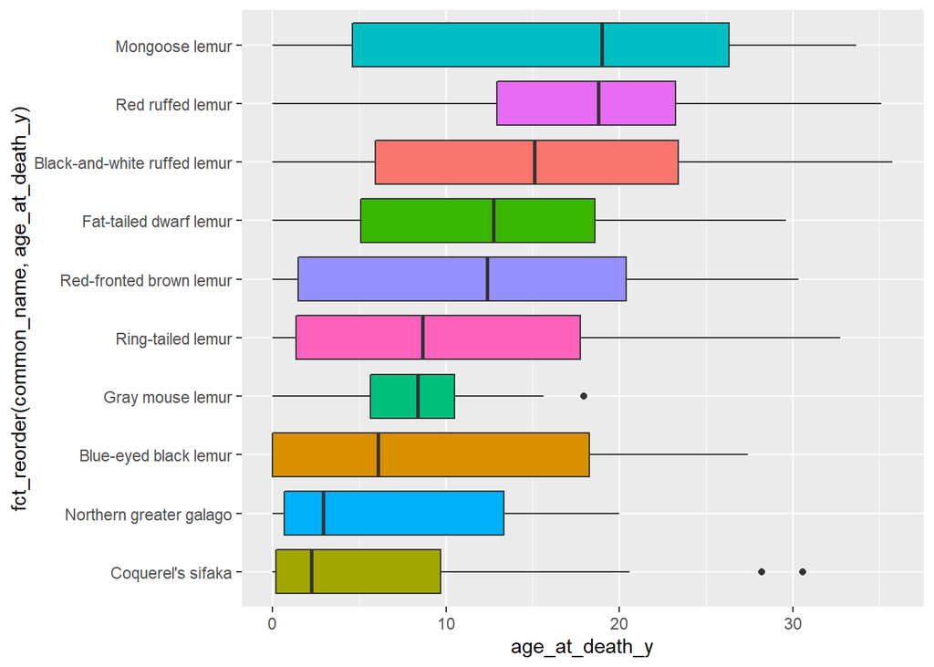

```r
top_species %>%
  filter(!is.na(dob) & !is.na(dod) & birth_type == "CB"
         & is.na(estimated_dob)) %>%
  ggplot()+
  geom_boxplot(aes(fill = common_name,
                   y = age_at_death_y,
                   x = fct_reorder(common_name, age_at_death_y)))+
  coord_flip()+
  theme(legend.position = "none")
```